# Proyecto 2_Entrega 1

Andre Jo

2025-03-02

```r
datos <- read.csv("test.csv")
submi <- read.csv("sample_submission.csv")

datos <- merge(datos, submi, by="Id")

datos_train <- read.csv("train.csv")

datos_train_uni <- datos_train[, c("LotArea", "SalePrice")]


head(datos)
```

```
##     Id MSSubClass MSZoning LotFrontage LotArea Street Alley LotShape
## 1 1461         20       RH          80   11622   Pave  <NA>      Reg
## 2 1462         20       RL          81   14267   Pave  <NA>      IR1
## 3 1463         60       RL          74   13830   Pave  <NA>      IR1
## 4 1464         60       RL          78    9978   Pave  <NA>      IR1
## 5 1465        120       RL          43    5005   Pave  <NA>      IR1
## 6 1466         60       RL          75   10000   Pave  <NA>      IR1
##   LandContour Utilities LotConfig LandSlope Neighborhood Condition1 Condition2
## 1         Lvl    AllPub    Inside       Gtl        NAmes      Feedr       Norm
## 2         Lvl    AllPub    Corner       Gtl        NAmes       Norm       Norm
## 3         Lvl    AllPub    Inside       Gtl      Gilbert       Norm       Norm
## 4         Lvl    AllPub    Inside       Gtl      Gilbert       Norm       Norm
## 5         HLS    AllPub    Inside       Gtl      StoneBr       Norm       Norm
## 6         Lvl    AllPub    Corner       Gtl      Gilbert       Norm       Norm
##   BldgType HouseStyle OverallQual OverallCond YearBuilt YearRemodAdd RoofStyle
```

[output cut: 69 more lines]

```r
head(datos_train)
```

```
##   Id MSSubClass MSZoning LotFrontage LotArea Street Alley LotShape LandContour
## 1  1         60       RL          65    8450   Pave  <NA>      Reg         Lvl
## 2  2         20       RL          80    9600   Pave  <NA>      Reg         Lvl
## 3  3         60       RL          68   11250   Pave  <NA>      IR1         Lvl
## 4  4         70       RL          60    9550   Pave  <NA>      IR1         Lvl
## 5  5         60       RL          84   14260   Pave  <NA>      IR1         Lvl
## 6  6         50       RL          85   14115   Pave  <NA>      IR1         Lvl
##   Utilities LotConfig LandSlope Neighborhood Condition1 Condition2 BldgType
## 1    AllPub    Inside       Gtl      CollgCr       Norm       Norm     1Fam
## 2    AllPub       FR2       Gtl      Veenker      Feedr       Norm     1Fam
## 3    AllPub    Inside       Gtl      CollgCr       Norm       Norm     1Fam
## 4    AllPub    Corner       Gtl      Crawfor       Norm       Norm     1Fam
## 5    AllPub       FR2       Gtl      NoRidge       Norm       Norm     1Fam
## 6    AllPub    Inside       Gtl      Mitchel       Norm       Norm     1Fam
##   HouseStyle OverallQual OverallCond YearBuilt YearRemodAdd RoofStyle RoofMatl
```

[output cut: 69 more lines]

Se selecciona la variable LotArea como la variable a medir. Se puede inferir que entre más area hay, más espacio ya sea para expandir o para realizar actividades puedan atraer a más personas por lo cual puede aumentar su precio de venta.

```r
fitLMPW<-lm(LotArea~SalePrice, data = datos_train_uni)
summary(fitLMPW)
```

```
##
## Call:
## lm(formula = LotArea ~ SalePrice, data = datos_train_uni)
##
## Residuals:
##    Min     1Q Median     3Q    Max
## -13593  -2751   -914   1140 198295
##
## Coefficients:
##              Estimate Std. Error t value Pr(>|t|)
## (Intercept) 4.519e+03  6.271e+02   7.207 9.16e-13 ***
## SalePrice   3.315e-02  3.174e-03  10.445  < 2e-16 ***
## ---
## Signif. codes:  0 '***' 0.001 '**' 0.01 '*' 0.05 '.' 0.1 ' ' 1
##
## Residual standard error: 9631 on 1458 degrees of freedom
## Multiple R-squared:  0.06961,    Adjusted R-squared:  0.06898
## F-statistic: 109.1 on 1 and 1458 DF,  p-value: < 2.2e-16
```

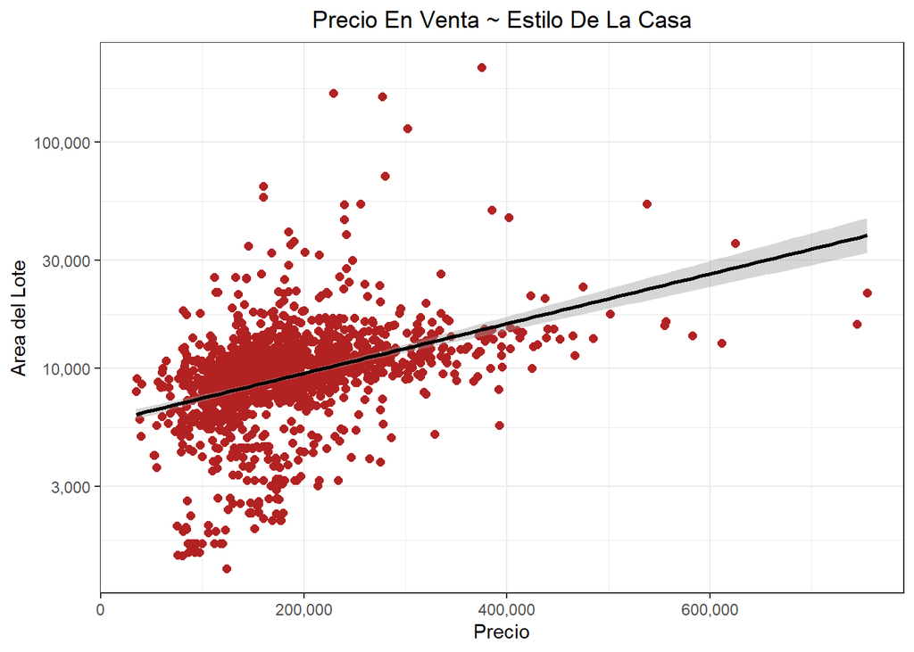

```r
ggplot(data = datos_train_uni, mapping = aes(x = SalePrice, y = LotArea)) +
geom_point(color = "firebrick", size = 2) +
geom_smooth(method = "lm", se = TRUE, color = "black") +
labs(title = "Precio En Venta ~ Estilo De La Casa", x = "Precio", y = "Area del Lote")+
  scale_x_continuous(labels = scales::comma) +  # Format large numbers with commas
  scale_y_log10(labels = scales::comma) +       # Use log scale for large LotArea value
theme_bw() + theme(plot.title = element_text(hjust = 0.5))
```

Se puede observar que la linea de tendencia se dirige hacia arriba. Esto puede significar que entre más area, más aumenta el precio. por lo tanto asumimos que toda la concentración de puntos son casas con menor area y con un precio menor. Por otro lado tambien observamos variabilidad con los datos donde se acercan a la linea lo cual indica que otras variables pueden afectar con el precio de venta de la casa.

Declarando las variable numericas del dataset

```r
datos <- datos[,  c("MSSubClass", "LotArea",  "OverallQual", "OverallCond",
                 "YearBuilt", "YearRemodAdd", "BsmtFinSF1", "BsmtFinSF2",
                 "BsmtUnfSF", "X1stFlrSF", "X2ndFlrSF", "LowQualFinSF",
                  "BsmtFullBath", "BsmtHalfBath", "FullBath", "HalfBath" ,
                 "BedroomAbvGr", "KitchenAbvGr", "TotRmsAbvGrd", "Fireplaces"
                 , "GarageCars", "GarageArea", "WoodDeckSF" , "OpenPorchSF", "EnclosedPorch"
                 , "X3SsnPorch", "ScreenPorch", "PoolArea", "MiscVal", "MoSold", "YrSold",
                 "SalePrice")]

datos_train <- datos_train[,  c("MSSubClass", "LotArea",  "OverallQual", "OverallCond",
                 "YearBuilt", "YearRemodAdd", "BsmtFinSF1", "BsmtFinSF2",
                 "BsmtUnfSF", "X1stFlrSF", "X2ndFlrSF", "LowQualFinSF",
                  "BsmtFullBath", "BsmtHalfBath", "FullBath", "HalfBath" ,
                 "BedroomAbvGr", "KitchenAbvGr", "TotRmsAbvGrd", "Fireplaces"
                 , "GarageCars", "GarageArea", "WoodDeckSF" , "OpenPorchSF", "EnclosedPorch"
                 , "X3SsnPorch", "ScreenPorch", "PoolArea", "MiscVal", "MoSold", "YrSold",
                 "SalePrice")]
```

```r
fitMLM_varSales<-lm(SalePrice~.,data = datos)
```

```r
summary(fitMLM_varSales)
```

```
##
## Call:
## lm(formula = SalePrice ~ ., data = datos)
##
## Residuals:
##        Min         1Q     Median         3Q        Max
## -2.040e-09 -3.340e-10 -4.300e-11  2.460e-10  7.049e-08
##
## Coefficients:
##                 Estimate Std. Error    t value Pr(>|t|)
## (Intercept)    1.918e+06  7.980e-08  2.403e+13  < 2e-16 ***
## MSSubClass    -4.103e-13  1.448e-12 -2.830e-01    0.777
## LotArea        1.968e+00  1.319e-14  1.492e+14  < 2e-16 ***
## OverallQual    3.375e-11  6.296e-11  5.360e-01    0.592
## OverallCond    2.462e-11  5.553e-11  4.430e-01    0.658
## YearBuilt      2.678e-12  3.190e-12  8.390e-01    0.401
## YearRemodAdd  -4.410e-12  3.685e-12 -1.197e+00    0.232
## BsmtFinSF1     1.957e-13  2.548e-13  7.680e-01    0.442
## BsmtFinSF2     2.623e-13  3.699e-13  7.090e-01    0.478
## BsmtUnfSF      5.349e-14  2.246e-13  2.380e-01    0.812
## X1stFlrSF     -5.068e-13  3.138e-13 -1.615e+00    0.107
## X2ndFlrSF     -1.479e-13  2.872e-13 -5.150e-01    0.607
## LowQualFinSF  -1.524e-13  1.181e-12 -1.290e-01    0.897
## BsmtFullBath  -1.744e-10  1.383e-10 -1.261e+00    0.207
## BsmtHalfBath  -2.618e-10  2.195e-10 -1.192e+00    0.233
## FullBath       5.045e-11  1.502e-10  3.360e-01    0.737
## HalfBath      -4.445e-11  1.485e-10 -2.990e-01    0.765
## BedroomAbvGr   1.328e+04  9.299e-11  1.428e+14  < 2e-16 ***
## KitchenAbvGr   1.220e-10  3.081e-10  3.960e-01    0.692
## TotRmsAbvGrd   4.199e-11  6.723e-11  6.250e-01    0.532
## Fireplaces    -4.133e-11  9.744e-11 -4.240e-01    0.672
## GarageCars    -6.552e-10  1.617e-10 -4.051e+00 5.39e-05 ***
## GarageArea     2.466e-12  5.610e-13  4.396e+00 1.19e-05 ***
## WoodDeckSF     3.203e-13  4.445e-13  7.210e-01    0.471
## OpenPorchSF   -4.895e-13  8.243e-13 -5.940e-01    0.553
## EnclosedPorch -2.966e-13  8.387e-13 -3.540e-01    0.724
## X3SsnPorch    -4.074e-13  2.523e-12 -1.610e-01    0.872
## ScreenPorch    1.406e-12  9.258e-13  1.518e+00    0.129
## PoolArea       6.605e-13  1.761e-12  3.750e-01    0.708
## MiscVal       -8.216e-15  8.533e-14 -9.600e-02    0.923
## MoSold         1.105e+03  1.899e-11  5.818e+13  < 2e-16 ***
## YrSold        -8.977e+02  3.966e-11 -2.264e+13  < 2e-16 ***
## ---
## Signif. codes:  0 '***' 0.001 '**' 0.01 '*' 0.05 '.' 0.1 ' ' 1
##
## Residual standard error: 1.916e-09 on 1424 degrees of freedom
##   (3 observations deleted due to missingness)
## Multiple R-squared:      1,  Adjusted R-squared:      1
## F-statistic: 3.398e+27 on 31 and 1424 DF,  p-value: < 2.2e-16
```

Se observa principalmente el $R^2$ ajustado y el multiple tienen un valor de 1 lo cual puede indicar un ajuste perfecto con los variables o puede ser que se analizaron muchas variables lo cual pueden ser irrelevantes como se explica en las siguientes gráficas. Además, al tener un ajuste perfecto puede indicar overfitting de las variables.

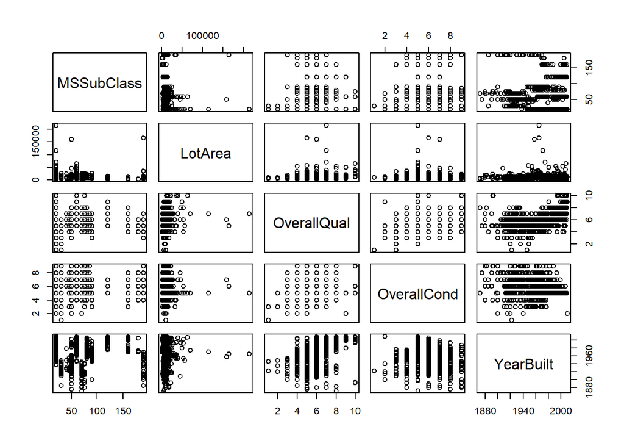

```r
plot(datos_train[,1:5])
```

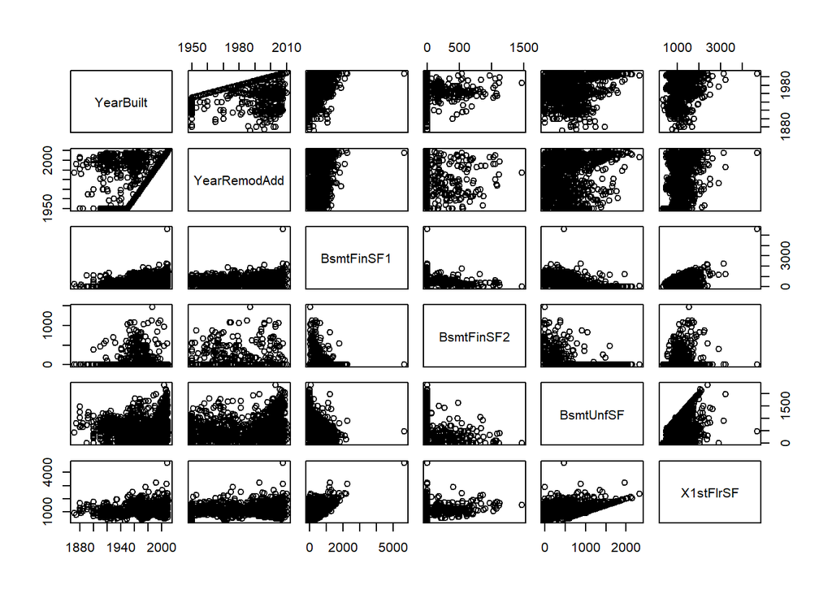

```r
plot(datos_train[,5:10])
```

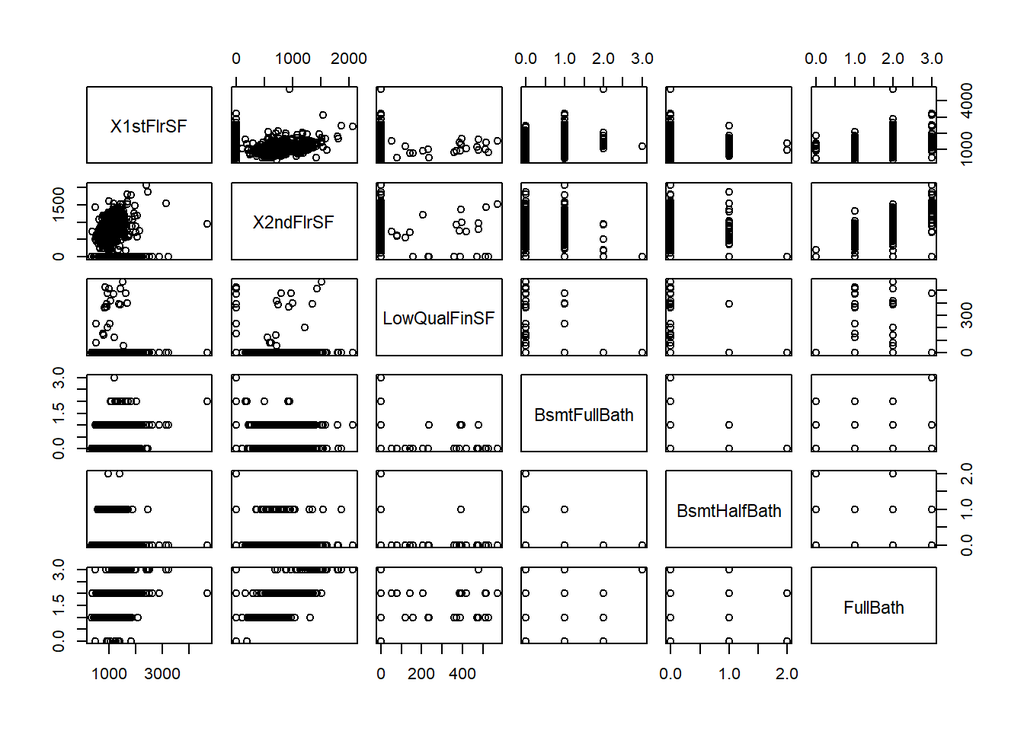

```r
plot(datos_train[,10:15])
```

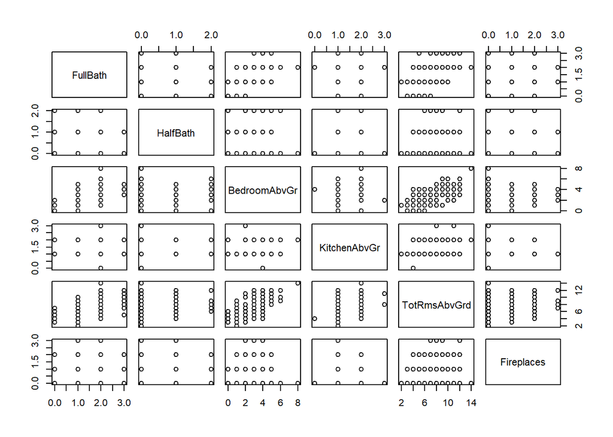

```r
plot(datos_train[,15:20])
```

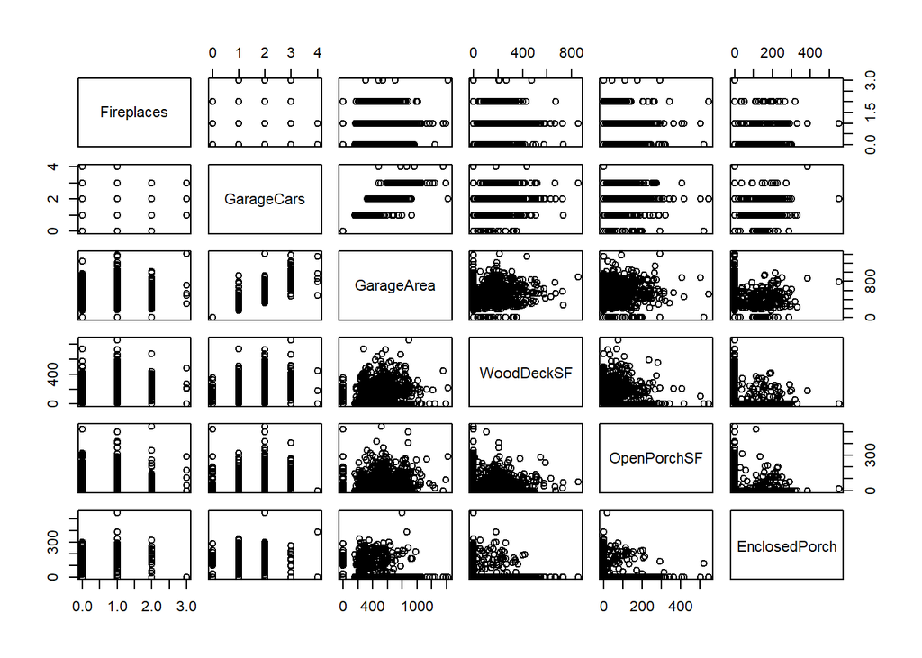

```r
plot(datos_train[,20:25])
```

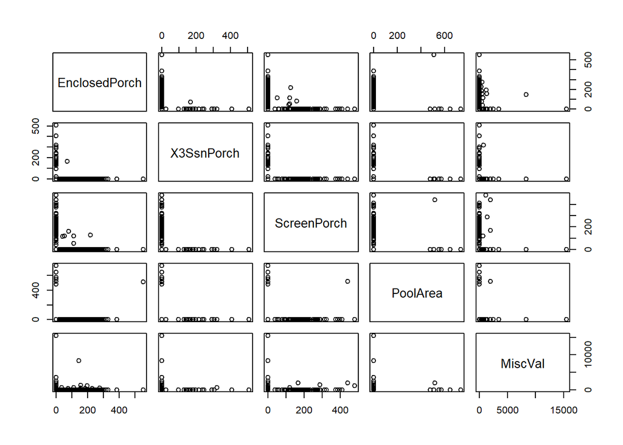

```r
plot(datos_train[,25:29])
```

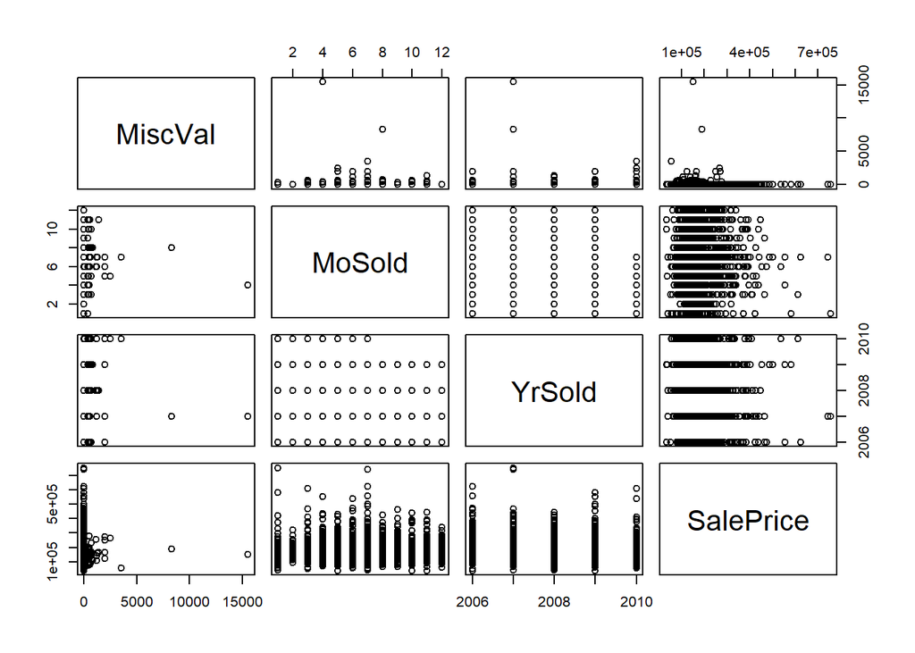

```r
plot(datos_train[,29:32])
```

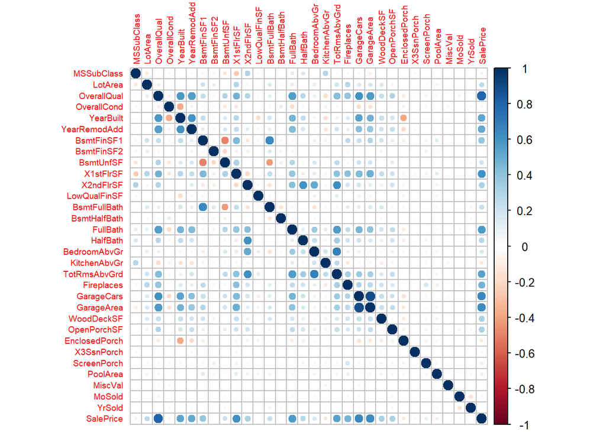

```r
matriz_cor <- cor(datos_train)
corrplot(matriz_cor, tl.cex = 0.6)
```

```r
datos <- datos[,  c("MSSubClass", "LotArea",  "OverallQual", "OverallCond",
                 "YearBuilt", "YearRemodAdd", "BsmtFinSF1", "BsmtFinSF2",
                 "BsmtUnfSF", "X1stFlrSF", "X2ndFlrSF", "LowQualFinSF",
                  "BsmtFullBath", "BsmtHalfBath", "FullBath", "HalfBath" ,
                 "BedroomAbvGr", "KitchenAbvGr", "Fireplaces",
                  "WoodDeckSF" , "OpenPorchSF", "EnclosedPorch"
                 , "X3SsnPorch", "ScreenPorch", "PoolArea", "MiscVal"  ,"YrSold",
                 "SalePrice")]

datos_train <- datos_train[,  c("MSSubClass", "LotArea",  "OverallQual", "OverallCond",
                 "YearBuilt", "YearRemodAdd", "BsmtFinSF1", "BsmtFinSF2",
                 "BsmtUnfSF", "X1stFlrSF", "X2ndFlrSF", "LowQualFinSF",
                  "BsmtFullBath", "BsmtHalfBath", "FullBath", "HalfBath" ,
                 "BedroomAbvGr", "KitchenAbvGr", "Fireplaces",
                  "WoodDeckSF" , "OpenPorchSF", "EnclosedPorch"
                 , "X3SsnPorch", "ScreenPorch", "PoolArea", "MiscVal", "YrSold",
                 "SalePrice")]
```

```r
fitMLM_varSales_noVar<-lm(SalePrice~.,data = datos)
```

```r
summary(fitMLM_varSales_noVar)
```

```
##
## Call:
## lm(formula = SalePrice ~ ., data = datos)
##
## Residuals:
##     Min      1Q  Median      3Q     Max
## -6972.4 -1998.2   -18.3  1819.8  7327.8
##
## Coefficients:
##                 Estimate Std. Error t value Pr(>|t|)
## (Intercept)    2.720e+06  1.211e+05  22.464  < 2e-16 ***
## MSSubClass     9.422e-01  2.220e+00   0.424  0.67132
## LotArea        1.944e+00  2.010e-02  96.715  < 2e-16 ***
## OverallQual   -1.376e+02  9.512e+01  -1.446  0.14826
## OverallCond   -1.013e+01  8.545e+01  -0.119  0.90562
## YearBuilt      8.142e-01  4.812e+00   0.169  0.86567
## YearRemodAdd   5.560e+00  5.660e+00   0.982  0.32612
## BsmtFinSF1    -5.494e-01  3.914e-01  -1.404  0.16063
## BsmtFinSF2    -6.704e-01  5.699e-01  -1.176  0.23965
## BsmtUnfSF     -4.187e-01  3.463e-01  -1.209  0.22680
## X1stFlrSF      6.473e-01  4.449e-01   1.455  0.14585
## X2ndFlrSF     -5.365e-01  3.892e-01  -1.378  0.16831
## LowQualFinSF   3.153e+00  1.798e+00   1.754  0.07972 .
## BsmtFullBath   2.536e+02  2.126e+02   1.193  0.23314
## BsmtHalfBath   3.708e+02  3.387e+02   1.095  0.27383
## FullBath       1.529e+02  2.271e+02   0.673  0.50095
## HalfBath       2.228e+02  2.285e+02   0.975  0.32950
## BedroomAbvGr   1.360e+04  1.303e+02 104.308  < 2e-16 ***
## KitchenAbvGr   2.331e+02  4.482e+02   0.520  0.60317
## Fireplaces     9.489e+01  1.495e+02   0.635  0.52569
## WoodDeckSF     3.584e-01  6.856e-01   0.523  0.60129
## OpenPorchSF   -1.516e-01  1.266e+00  -0.120  0.90472
## EnclosedPorch  5.288e-01  1.292e+00   0.409  0.68227
## X3SsnPorch     4.678e+00  3.890e+00   1.202  0.22939
## ScreenPorch    1.821e+00  1.426e+00   1.277  0.20169
## PoolArea      -7.306e+00  2.711e+00  -2.695  0.00712 **
## MiscVal        1.000e-01  1.312e-01   0.763  0.44585
## YrSold        -1.300e+03  6.016e+01 -21.617  < 2e-16 ***
## ---
## Signif. codes:  0 '***' 0.001 '**' 0.01 '*' 0.05 '.' 0.1 ' ' 1
##
## Residual standard error: 2960 on 1429 degrees of freedom
##   (2 observations deleted due to missingness)
## Multiple R-squared:  0.9676, Adjusted R-squared:  0.967
## F-statistic:  1583 on 27 and 1429 DF,  p-value: < 2.2e-16
```

Se observa que $R^2$ ajustado y el multiple ya no es perfecto pero es razonable ya que es mayor a 90%

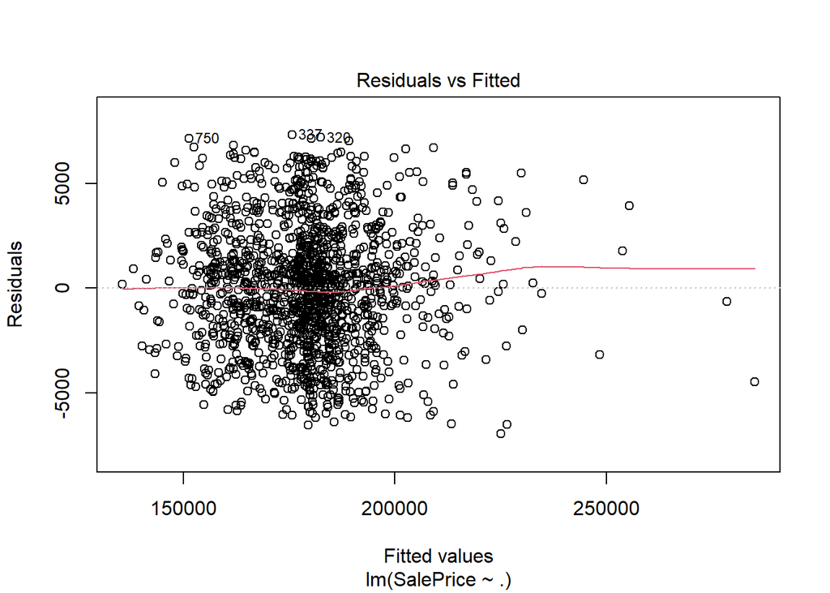

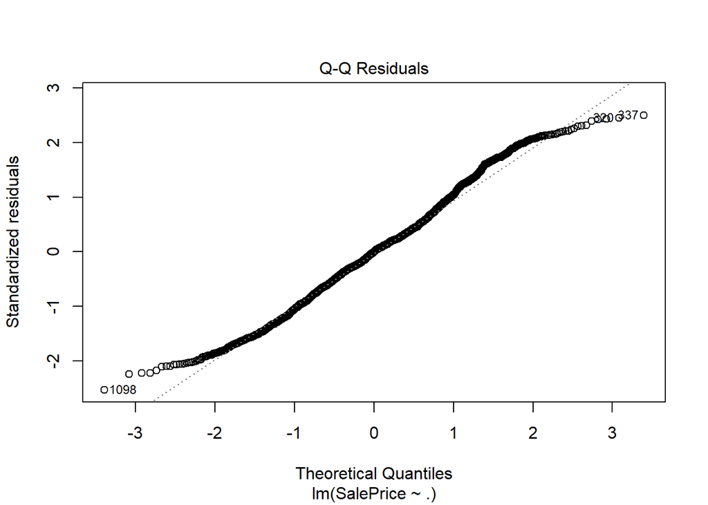

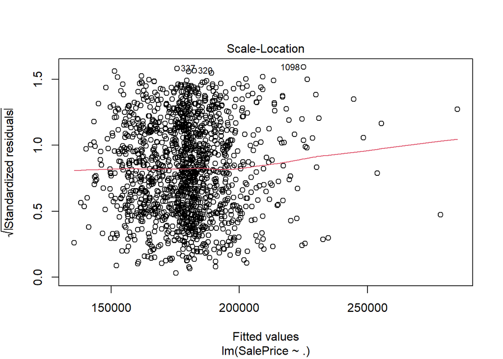

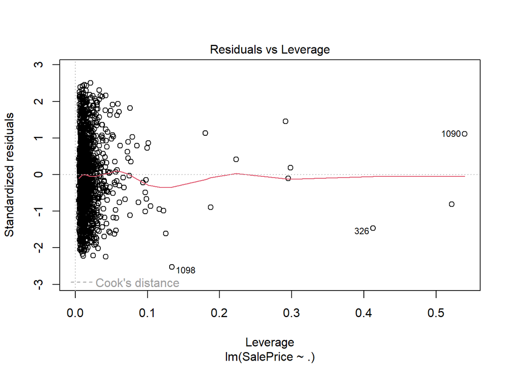

```r
plot(fitMLM_varSales_noVar)
```

En los gráficos se pueden ver que los residuos están aleatoriamente distribuidos alrededor de 0 y que no siguen ningún patrón. Si bien el gráfico q-q parece que no siguen una distribución normal como se puede observa en las cola inicial y cola del final por esta razón, necesitamos realizar la prueba de Kolmogorov-Smirnov.

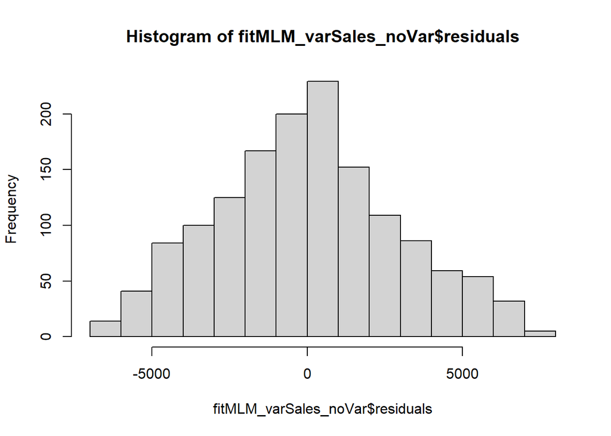

```r
hist(fitMLM_varSales_noVar$residuals)
```

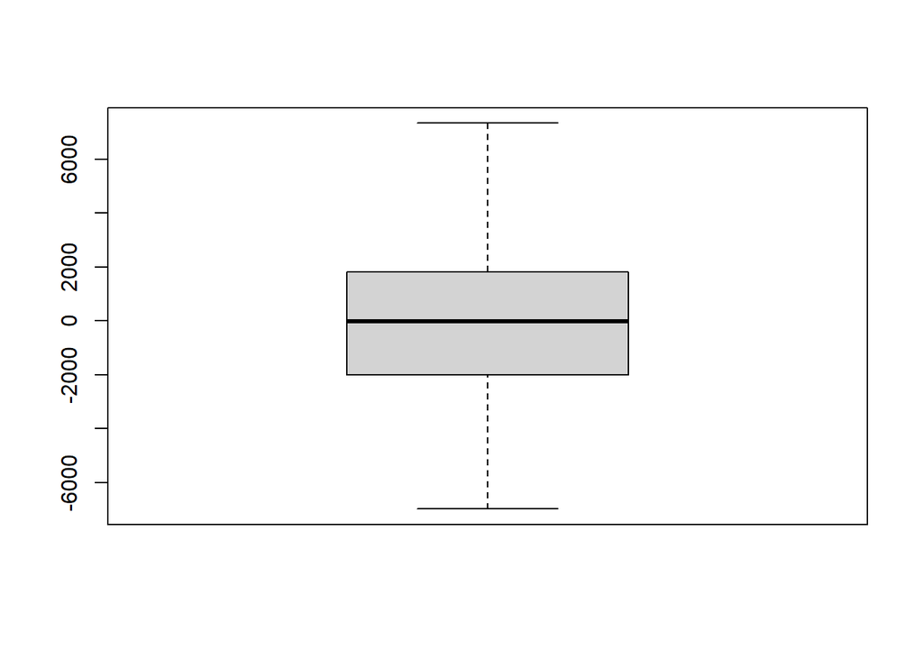

```r
boxplot(fitMLM_varSales_noVar$residuals)
```

Se observa que en la caja y bigote no tiene puntos atipicos y la distribución se asimila pero no es normal.

```r
lillie.test(fitMLM_varSales_noVar$residuals)
```

```
##
##  Lilliefors (Kolmogorov-Smirnov) normality test
##
## data:  fitMLM_varSales_noVar$residuals
## D = 0.03165, p-value = 0.001651
```

```r
predMLM<-predict(fitMLM_varSales_noVar,newdata = datos_train)
RMSE(predMLM,datos_train$SalePrice)
```

```
## [1] 75818.32
```

El RMSE es de 75,818.32 donde indica que, las predicciones del modelo se desvían del precio real de venta en esa cantidad. Si los precios de las casas son elevados, el error puede ser aceptable pero cuando los precios de las casas son bajos el error si puede afectar gravemente.

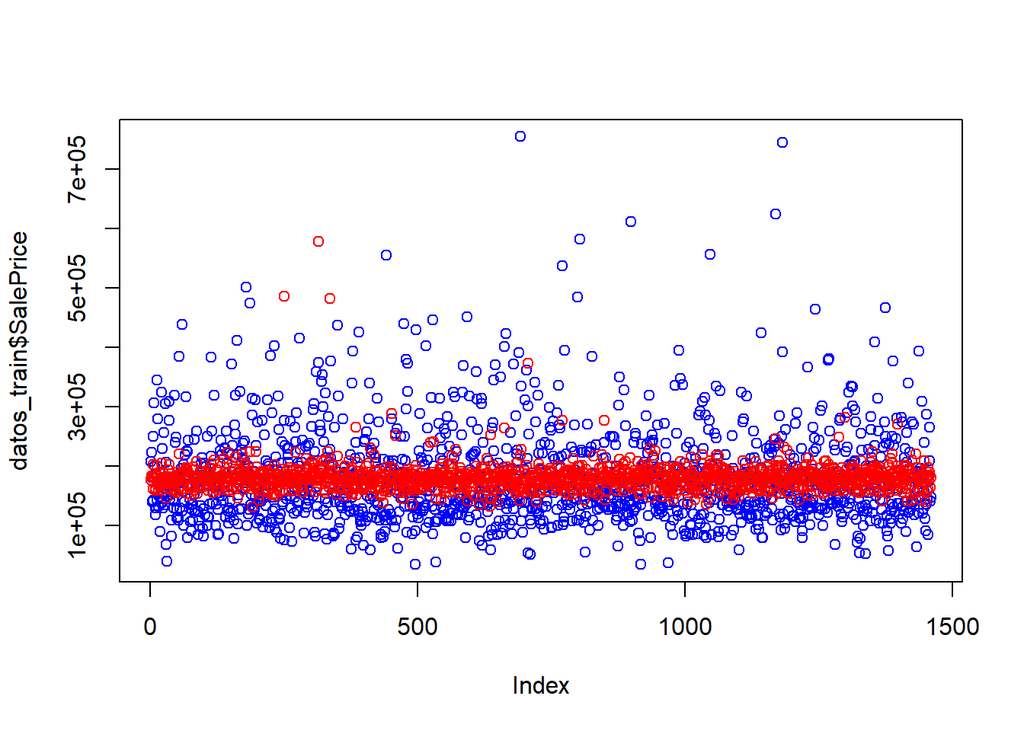

```r
plot(datos_train$SalePrice,col="blue")
points(predMLM, col="red")
```

```r
summary(datos_train$SalePrice-predMLM)
```

```
##      Min.   1st Qu.    Median      Mean   3rd Qu.      Max.
## -253866.4  -48904.8  -17452.9     276.8   30982.4  542769.0
```